# Diwali Sales Analysis

1.The focus of this project lies in conducting an in-depth analysis of Diwali sales.  
2.The dataset under scrutiny comprises a total of 11,251 rows and 15 columns.  
3.Leveraging tools such as pandas, numpy, and data visualization techniques, this analysis aims to uncover meaningful insights through exploratory data analysis.  
4.The ultimate goal is to draw informed conclusions based on the comprehensive examination of the Diwali sales data.

```python
#import python libraries:
import numpy as np
import pandas as pd

#import data visulization:
import matplotlib.pyplot as plt
%matplotlib inline
import seaborn as sns
import cufflinks as cf
cf.go_offline
```

```
<function cufflinks.offline.go_offline(connected=None)>
```

# Let's read the dataset and Exploratory data analysis

```python
df=pd.read_csv('Diwali_Sales_Data1.csv',encoding='unicode_escape')
df
```

|  | User_ID | Cust_name | Product_ID | Gender | Age Group | Age | Marital_Status | State | Zone | Occupation | Product_Category | Orders | Amount | Status | unnamed1 |
| --- | --- | --- | --- | --- | --- | --- | --- | --- | --- | --- | --- | --- | --- | --- | --- |
| 0 | 1002903 | Sanskriti | P00125942 | F | 26-35 | 28 | 0 | Maharashtra | Western | Healthcare | Auto | 1 | 23952.0 | NaN | NaN |
| 1 | 1000732 | Kartik | P00110942 | F | 26-35 | 35 | 1 | Andhra Pradesh | Southern | Govt | Auto | 3 | 23934.0 | NaN | NaN |
| 2 | 1001990 | Bindu | P00118542 | F | 26-35 | 35 | 1 | Uttar Pradesh | Central | Automobile | Auto | 3 | 23924.0 | NaN | NaN |
| 3 | 1001425 | Sudevi | P00237842 | M | 0-17 | 16 | 0 | Karnataka | Southern | Construction | Auto | 2 | 23912.0 | NaN | NaN |
| 4 | 1000588 | Joni | P00057942 | M | 26-35 | 28 | 1 | Gujarat | Western | Food Processing | Auto | 2 | 23877.0 | NaN | NaN |
| ... | ... | ... | ... | ... | ... | ... | ... | ... | ... | ... | ... | ... | ... | ... | ... |
| 11246 | 1000695 | Manning | P00296942 | M | 18-25 | 19 | 1 | Maharashtra | Western | Chemical | Office | 4 | 370.0 | NaN | NaN |
| 11247 | 1004089 | Reichenbach | P00171342 | M | 26-35 | 33 | 0 | Haryana | Northern | Healthcare | Veterinary | 3 | 367.0 | NaN | NaN |
| 11248 | 1001209 | Oshin | P00201342 | F | 36-45 | 40 | 0 | Madhya Pradesh | Central | Textile | Office | 4 | 213.0 | NaN | NaN |
| 11249 | 1004023 | Noonan | P00059442 | M | 36-45 | 37 | 0 | Karnataka | Southern | Agriculture | Office | 3 | 206.0 | NaN | NaN |
| 11250 | 1002744 | Brumley | P00281742 | F | 18-25 | 19 | 0 | Maharashtra | Western | Healthcare | Office | 3 | 188.0 | NaN | NaN |

11251 rows × 15 columns

```python
df.shape
```

```
(11251, 15)
```

```python
df.head()
```

|  | User_ID | Cust_name | Product_ID | Gender | Age Group | Age | Marital_Status | State | Zone | Occupation | Product_Category | Orders | Amount | Status | unnamed1 |
| --- | --- | --- | --- | --- | --- | --- | --- | --- | --- | --- | --- | --- | --- | --- | --- |
| 0 | 1002903 | Sanskriti | P00125942 | F | 26-35 | 28 | 0 | Maharashtra | Western | Healthcare | Auto | 1 | 23952.0 | NaN | NaN |
| 1 | 1000732 | Kartik | P00110942 | F | 26-35 | 35 | 1 | Andhra Pradesh | Southern | Govt | Auto | 3 | 23934.0 | NaN | NaN |
| 2 | 1001990 | Bindu | P00118542 | F | 26-35 | 35 | 1 | Uttar Pradesh | Central | Automobile | Auto | 3 | 23924.0 | NaN | NaN |
| 3 | 1001425 | Sudevi | P00237842 | M | 0-17 | 16 | 0 | Karnataka | Southern | Construction | Auto | 2 | 23912.0 | NaN | NaN |
| 4 | 1000588 | Joni | P00057942 | M | 26-35 | 28 | 1 | Gujarat | Western | Food Processing | Auto | 2 | 23877.0 | NaN | NaN |

```python
df.info()
```

```
<class 'pandas.core.frame.DataFrame'>
RangeIndex: 11251 entries, 0 to 11250
Data columns (total 15 columns):
 #   Column            Non-Null Count  Dtype
---  ------            --------------  -----
 0   User_ID           11251 non-null  int64
 1   Cust_name         11251 non-null  object
 2   Product_ID        11251 non-null  object
 3   Gender            11251 non-null  object
 4   Age Group         11251 non-null  object
 5   Age               11251 non-null  int64
 6   Marital_Status    11251 non-null  int64
 7   State             11251 non-null  object
 8   Zone              11251 non-null  object
 9   Occupation        11251 non-null  object
 10  Product_Category  11251 non-null  object
 11  Orders            11251 non-null  int64
 12  Amount            11239 non-null  float64
 13  Status            0 non-null      float64
 14  unnamed1          0 non-null      float64
dtypes: float64(3), int64(4), object(8)
memory usage: 1.3+ MB
```

```python
#Descriptive statistics summary:
df.describe()
```

|  | User_ID | Age | Marital_Status | Orders | Amount | Status | unnamed1 |
| --- | --- | --- | --- | --- | --- | --- | --- |
| count | 1.125100e+04 | 11251.000000 | 11251.000000 | 11251.000000 | 11239.000000 | 0.0 | 0.0 |
| mean | 1.003004e+06 | 35.421207 | 0.420318 | 2.489290 | 9453.610858 | NaN | NaN |
| std | 1.716125e+03 | 12.754122 | 0.493632 | 1.115047 | 5222.355869 | NaN | NaN |
| min | 1.000001e+06 | 12.000000 | 0.000000 | 1.000000 | 188.000000 | NaN | NaN |
| 25% | 1.001492e+06 | 27.000000 | 0.000000 | 1.500000 | 5443.000000 | NaN | NaN |
| 50% | 1.003065e+06 | 33.000000 | 0.000000 | 2.000000 | 8109.000000 | NaN | NaN |
| 75% | 1.004430e+06 | 43.000000 | 1.000000 | 3.000000 | 12675.000000 | NaN | NaN |
| max | 1.006040e+06 | 92.000000 | 1.000000 | 4.000000 | 23952.000000 | NaN | NaN |

# Data Cleaning

```python
#Missing data/ Check the null value or empty values:
total=df.isnull().sum().sort_values(ascending=False)
percent=(df.isnull().sum()/df.isnull().count()).sort_values(ascending=False)

missing_data=pd.concat([total,percent],axis=1,keys=['Total','Percent'])
missing_data
```

|  | Total | Percent |
| --- | --- | --- |
| Status | 11251 | 1.000000 |
| unnamed1 | 11251 | 1.000000 |
| Amount | 12 | 0.001067 |
| User_ID | 0 | 0.000000 |
| Cust_name | 0 | 0.000000 |
| Product_ID | 0 | 0.000000 |
| Gender | 0 | 0.000000 |
| Age Group | 0 | 0.000000 |
| Age | 0 | 0.000000 |
| Marital_Status | 0 | 0.000000 |
| State | 0 | 0.000000 |
| Zone | 0 | 0.000000 |
| Occupation | 0 | 0.000000 |
| Product_Category | 0 | 0.000000 |
| Orders | 0 | 0.000000 |

```python
#Drop the values:
df.drop(['Status', 'unnamed1'] , axis=1 ,inplace=True)
```

```python
df
```

|  | User_ID | Cust_name | Product_ID | Gender | Age Group | Age | Marital_Status | State | Zone | Occupation | Product_Category | Orders | Amount |
| --- | --- | --- | --- | --- | --- | --- | --- | --- | --- | --- | --- | --- | --- |
| 0 | 1002903 | Sanskriti | P00125942 | F | 26-35 | 28 | 0 | Maharashtra | Western | Healthcare | Auto | 1 | 23952.0 |
| 1 | 1000732 | Kartik | P00110942 | F | 26-35 | 35 | 1 | Andhra Pradesh | Southern | Govt | Auto | 3 | 23934.0 |
| 2 | 1001990 | Bindu | P00118542 | F | 26-35 | 35 | 1 | Uttar Pradesh | Central | Automobile | Auto | 3 | 23924.0 |
| 3 | 1001425 | Sudevi | P00237842 | M | 0-17 | 16 | 0 | Karnataka | Southern | Construction | Auto | 2 | 23912.0 |
| 4 | 1000588 | Joni | P00057942 | M | 26-35 | 28 | 1 | Gujarat | Western | Food Processing | Auto | 2 | 23877.0 |
| ... | ... | ... | ... | ... | ... | ... | ... | ... | ... | ... | ... | ... | ... |
| 11246 | 1000695 | Manning | P00296942 | M | 18-25 | 19 | 1 | Maharashtra | Western | Chemical | Office | 4 | 370.0 |
| 11247 | 1004089 | Reichenbach | P00171342 | M | 26-35 | 33 | 0 | Haryana | Northern | Healthcare | Veterinary | 3 | 367.0 |
| 11248 | 1001209 | Oshin | P00201342 | F | 36-45 | 40 | 0 | Madhya Pradesh | Central | Textile | Office | 4 | 213.0 |
| 11249 | 1004023 | Noonan | P00059442 | M | 36-45 | 37 | 0 | Karnataka | Southern | Agriculture | Office | 3 | 206.0 |
| 11250 | 1002744 | Brumley | P00281742 | F | 18-25 | 19 | 0 | Maharashtra | Western | Healthcare | Office | 3 | 188.0 |

11251 rows × 13 columns

```python
#Dropna is specific columns:
df.dropna(subset='Amount',inplace=True)
```

```python
#Change data type in amount:
df['Amount']=df['Amount'].astype('int')
```

```python
#Duplicates:
df.duplicated().sum()
```

```
8
```

```python
#Remove the duplicated values:
df.drop_duplicates(inplace=True)
```

```python
df.shape
```

```
(11231, 13)
```

```python
df.head(30)
```

|  | User_ID | Cust_name | Product_ID | Gender | Age Group | Age | Marital_Status | State | Zone | Occupation | Product_Category | Orders | Amount |
| --- | --- | --- | --- | --- | --- | --- | --- | --- | --- | --- | --- | --- | --- |
| 0 | 1002903 | Sanskriti | P00125942 | F | 26-35 | 28 | 0 | Maharashtra | Western | Healthcare | Auto | 1 | 23952 |
| 1 | 1000732 | Kartik | P00110942 | F | 26-35 | 35 | 1 | Andhra Pradesh | Southern | Govt | Auto | 3 | 23934 |
| 2 | 1001990 | Bindu | P00118542 | F | 26-35 | 35 | 1 | Uttar Pradesh | Central | Automobile | Auto | 3 | 23924 |
| 3 | 1001425 | Sudevi | P00237842 | M | 0-17 | 16 | 0 | Karnataka | Southern | Construction | Auto | 2 | 23912 |
| 4 | 1000588 | Joni | P00057942 | M | 26-35 | 28 | 1 | Gujarat | Western | Food Processing | Auto | 2 | 23877 |
| 5 | 1000588 | Joni | P00057942 | M | 26-35 | 28 | 1 | Himachal Pradesh | Northern | Food Processing | Auto | 1 | 23877 |
| 6 | 1001132 | Balk | P00018042 | F | 18-25 | 25 | 1 | Uttar Pradesh | Central | Lawyer | Auto | 4 | 23841 |
| 8 | 1003224 | Kushal | P00205642 | M | 26-35 | 35 | 0 | Uttar Pradesh | Central | Govt | Auto | 2 | 23809 |
| 9 | 1003650 | Ginny | P00031142 | F | 26-35 | 26 | 1 | Andhra Pradesh | Southern | Media | Auto | 4 | 23799 |
| 10 | 1003829 | Harshita | P00200842 | M | 26-35 | 34 | 0 | Delhi | Central | Banking | Auto | 1 | 23770 |
| 11 | 1000214 | Kargatis | P00119142 | F | 18-25 | 20 | 0 | Andhra Pradesh | Southern | Retail | Auto | 2 | 23752 |
| 12 | 1004035 | Elijah | P00080342 | F | 18-25 | 20 | 1 | Andhra Pradesh | Southern | IT Sector | Auto | 2 | 23730 |
| 13 | 1001680 | Vasudev | P00324942 | M | 26-35 | 26 | 1 | Andhra Pradesh | Southern | Automobile | Auto | 4 | 23718 |
| 15 | 1000813 | Lauren | P00289942 | F | 18-25 | 24 | 0 | Andhra Pradesh | Southern | Govt | Auto | 2 | 23664 |
| 17 | 1001193 | Mick | P00004842 | F | 26-35 | 29 | 0 | Andhra Pradesh | Southern | Aviation | Auto | 1 | 23619 |
| 18 | 1001883 | Praneet | P00029842 | M | 51-55 | 54 | 1 | Uttar Pradesh | Central | Hospitality | Auto | 1 | 23568 |
| 20 | 1000113 | Ellis | P00180642 | F | 18-25 | 19 | 1 | Andhra Pradesh | Southern | Govt | Auto | 4 | 23546 |
| 21 | 1000416 | Hrisheekesh | P00181842 | F | 46-50 | 46 | 1 | Uttar Pradesh | Central | Banking | Auto | 2 | 23525 |
| 22 | 1005256 | Grant | P00101742 | F | 26-35 | 30 | 0 | Andhra Pradesh | Southern | IT Sector | Auto | 1 | 23518 |
| 23 | 1001505 | Gilcrest | P00271842 | F | 51-55 | 53 | 0 | Uttar Pradesh | Central | Automobile | Auto | 2 | 23515 |
| 24 | 1000900 | Skaria | P00317842 | M | 55+ | 83 | 0 | Karnataka | Southern | Automobile | Auto | 3 | 23513 |
| 25 | 1005908 | Eric | P00282642 | F | 26-35 | 33 | 0 | Andhra Pradesh | Southern | IT Sector | Auto | 3 | 23462 |
| 26 | 1001101 | Gibson | P00234742 | F | 36-45 | 40 | 0 | Uttar Pradesh | Central | Banking | Auto | 3 | 23456 |
| 27 | 1004736 | Mahima | P00058042 | F | 18-25 | 25 | 1 | Andhra Pradesh | Southern | Banking | Auto | 4 | 23451 |
| 28 | 1004037 | Etezadi | P00190542 | M | 51-55 | 54 | 1 | Andhra Pradesh | Southern | Govt | Hand & Power Tools | 2 | 23434 |
| 29 | 1002340 | James | P00119642 | F | 36-45 | 39 | 1 | Andhra Pradesh | Southern | Aviation | Auto | 3 | 23389 |
| 30 | 1005664 | Dean | P00111642 | F | 18-25 | 20 | 0 | Andhra Pradesh | Southern | Aviation | Auto | 2 | 23365 |
| 31 | 1002523 | Aman | P00293342 | F | 26-35 | 32 | 1 | Andhra Pradesh | Southern | Food Processing | Auto | 3 | 23326 |
| 32 | 1002503 | Mousam | P00220042 | F | 36-45 | 36 | 0 | Andhra Pradesh | Southern | Automobile | Auto | 2 | 23314 |
| 33 | 1002638 | Damala | P00346242 | F | 26-35 | 35 | 1 | Maharashtra | Western | Media | Auto | 2 | 23306 |

```python
#Identy the duplicates values in specific columns:
df[df["User_ID"].duplicated(keep='first')].head(10)
```

|  | User_ID | Cust_name | Product_ID | Gender | Age Group | Age | Marital_Status | State | Zone | Occupation | Product_Category | Orders | Amount |
| --- | --- | --- | --- | --- | --- | --- | --- | --- | --- | --- | --- | --- | --- |
| 5 | 1000588 | Joni | P00057942 | M | 26-35 | 28 | 1 | Himachal Pradesh | Northern | Food Processing | Auto | 1 | 23877 |
| 102 | 1004957 | Inderpreet | P00163442 | F | 26-35 | 34 | 1 | Delhi | Central | Healthcare | Footwear & Shoes | 1 | 20914 |
| 133 | 1003311 | Neola | P00228142 | F | 26-35 | 30 | 1 | Karnataka | Southern | Hospitality | Footwear & Shoes | 3 | 20815 |
| 139 | 1000838 | Divyeshkumar | P00363542 | M | 51-55 | 53 | 1 | Rajasthan | Northern | Hospitality | Footwear & Shoes | 2 | 20796 |
| 141 | 1000850 | Bhawna | P00324342 | M | 36-45 | 40 | 1 | Karnataka | Southern | IT Sector | Footwear & Shoes | 3 | 20783 |
| 169 | 1000687 | Neola | P00344542 | M | 26-35 | 26 | 0 | Delhi | Central | Chemical | Tupperware | 4 | 20668 |
| 175 | 1001015 | Bharat | P00109842 | M | 36-45 | 40 | 0 | Delhi | Central | Food Processing | Footwear & Shoes | 3 | 20660 |
| 192 | 1003311 | Neola | P00180442 | F | 26-35 | 29 | 0 | Delhi | Central | IT Sector | Footwear & Shoes | 3 | 20608 |
| 208 | 1004161 | Murray | P00265242 | F | 46-50 | 50 | 1 | Uttar Pradesh | Central | Banking | Furniture | 1 | 20588 |
| 224 | 1003618 | Keshav | P00233442 | M | 18-25 | 19 | 0 | Bihar | Eastern | Aviation | Footwear & Shoes | 2 | 20548 |

```python
#Remove the specific the columns:
df.drop_duplicates(subset="User_ID", inplace=True)
```

```python
df.head(20)
```

|  | User_ID | Cust_name | Product_ID | Gender | Age Group | Age | Marital_Status | State | Zone | Occupation | Product_Category | Orders | Amount |
| --- | --- | --- | --- | --- | --- | --- | --- | --- | --- | --- | --- | --- | --- |
| 0 | 1002903 | Sanskriti | P00125942 | F | 26-35 | 28 | 0 | Maharashtra | Western | Healthcare | Auto | 1 | 23952 |
| 1 | 1000732 | Kartik | P00110942 | F | 26-35 | 35 | 1 | Andhra Pradesh | Southern | Govt | Auto | 3 | 23934 |
| 2 | 1001990 | Bindu | P00118542 | F | 26-35 | 35 | 1 | Uttar Pradesh | Central | Automobile | Auto | 3 | 23924 |
| 3 | 1001425 | Sudevi | P00237842 | M | 0-17 | 16 | 0 | Karnataka | Southern | Construction | Auto | 2 | 23912 |
| 4 | 1000588 | Joni | P00057942 | M | 26-35 | 28 | 1 | Gujarat | Western | Food Processing | Auto | 2 | 23877 |
| 6 | 1001132 | Balk | P00018042 | F | 18-25 | 25 | 1 | Uttar Pradesh | Central | Lawyer | Auto | 4 | 23841 |
| 8 | 1003224 | Kushal | P00205642 | M | 26-35 | 35 | 0 | Uttar Pradesh | Central | Govt | Auto | 2 | 23809 |
| 9 | 1003650 | Ginny | P00031142 | F | 26-35 | 26 | 1 | Andhra Pradesh | Southern | Media | Auto | 4 | 23799 |
| 10 | 1003829 | Harshita | P00200842 | M | 26-35 | 34 | 0 | Delhi | Central | Banking | Auto | 1 | 23770 |
| 11 | 1000214 | Kargatis | P00119142 | F | 18-25 | 20 | 0 | Andhra Pradesh | Southern | Retail | Auto | 2 | 23752 |
| 12 | 1004035 | Elijah | P00080342 | F | 18-25 | 20 | 1 | Andhra Pradesh | Southern | IT Sector | Auto | 2 | 23730 |
| 13 | 1001680 | Vasudev | P00324942 | M | 26-35 | 26 | 1 | Andhra Pradesh | Southern | Automobile | Auto | 4 | 23718 |
| 15 | 1000813 | Lauren | P00289942 | F | 18-25 | 24 | 0 | Andhra Pradesh | Southern | Govt | Auto | 2 | 23664 |
| 17 | 1001193 | Mick | P00004842 | F | 26-35 | 29 | 0 | Andhra Pradesh | Southern | Aviation | Auto | 1 | 23619 |
| 18 | 1001883 | Praneet | P00029842 | M | 51-55 | 54 | 1 | Uttar Pradesh | Central | Hospitality | Auto | 1 | 23568 |
| 20 | 1000113 | Ellis | P00180642 | F | 18-25 | 19 | 1 | Andhra Pradesh | Southern | Govt | Auto | 4 | 23546 |
| 21 | 1000416 | Hrisheekesh | P00181842 | F | 46-50 | 46 | 1 | Uttar Pradesh | Central | Banking | Auto | 2 | 23525 |
| 22 | 1005256 | Grant | P00101742 | F | 26-35 | 30 | 0 | Andhra Pradesh | Southern | IT Sector | Auto | 1 | 23518 |
| 23 | 1001505 | Gilcrest | P00271842 | F | 51-55 | 53 | 0 | Uttar Pradesh | Central | Automobile | Auto | 2 | 23515 |
| 24 | 1000900 | Skaria | P00317842 | M | 55+ | 83 | 0 | Karnataka | Southern | Automobile | Auto | 3 | 23513 |

```python
df['User_ID'].duplicated().sum()
```

```
0
```

```python
df.shape
```

```
(3752, 13)
```

```python
df
```

|  | User_ID | Cust_name | Product_ID | Gender | Age Group | Age | Marital_Status | State | Zone | Occupation | Product_Category | Orders | Amount |
| --- | --- | --- | --- | --- | --- | --- | --- | --- | --- | --- | --- | --- | --- |
| 0 | 1002903 | Sanskriti | P00125942 | F | 26-35 | 28 | 0 | Maharashtra | Western | Healthcare | Auto | 1 | 23952 |
| 1 | 1000732 | Kartik | P00110942 | F | 26-35 | 35 | 1 | Andhra Pradesh | Southern | Govt | Auto | 3 | 23934 |
| 2 | 1001990 | Bindu | P00118542 | F | 26-35 | 35 | 1 | Uttar Pradesh | Central | Automobile | Auto | 3 | 23924 |
| 3 | 1001425 | Sudevi | P00237842 | M | 0-17 | 16 | 0 | Karnataka | Southern | Construction | Auto | 2 | 23912 |
| 4 | 1000588 | Joni | P00057942 | M | 26-35 | 28 | 1 | Gujarat | Western | Food Processing | Auto | 2 | 23877 |
| ... | ... | ... | ... | ... | ... | ... | ... | ... | ... | ... | ... | ... | ... |
| 11218 | 1003606 | Meg | P00157542 | M | 26-35 | 32 | 0 | Karnataka | Southern | Chemical | Office | 4 | 582 |
| 11219 | 1004268 | Rosenblatt | P00302942 | M | 46-50 | 48 | 0 | Himachal Pradesh | Northern | Govt | Office | 4 | 580 |
| 11223 | 1001542 | Buch | P00113642 | F | 18-25 | 20 | 1 | Maharashtra | Western | Aviation | Office | 4 | 574 |
| 11224 | 1004378 | Kritika | P00274042 | F | 18-25 | 18 | 0 | Delhi | Central | Aviation | Office | 2 | 572 |
| 11230 | 1005258 | Aromal | P00220442 | F | 36-45 | 37 | 1 | Delhi | Central | Banking | Office | 3 | 567 |

3752 rows × 13 columns

# Data Visulization

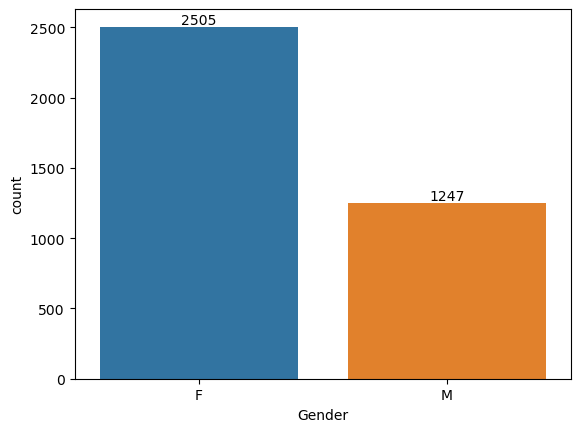

```python
#Gender:
#1.Count of gender:
gender_count=sns.countplot(x='Gender',data=df)

for i in gender_count.containers:
    gender_count.bar_label(i)
```

*Count of gender is more females shopping the product when compared to males.*

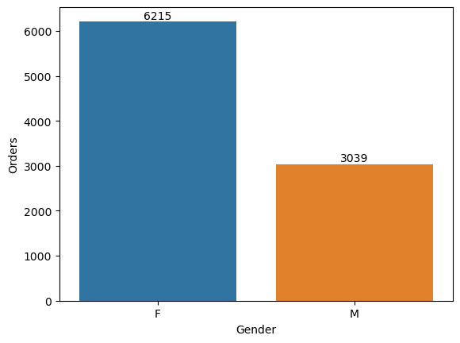

```python
#2.Which gender is more order the product/items:
gender1=df.groupby(['Gender'],as_index=False)['Orders'].sum().sort_values(by='Orders',ascending=False)

gender1_count=sns.barplot(x='Gender',y='Orders',data=gender1)

for i in gender1_count.containers:
    gender1_count.bar_label(i)
```

*Females is more orders the product when compared to males.*

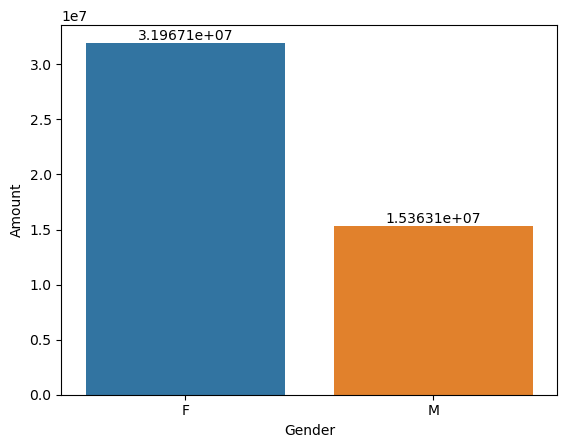

```python
#3.Which gender is more spending the money:
gender3=df.groupby(['Gender'],as_index=False)['Amount'].sum().sort_values(by='Amount',ascending=False)

gender3_count=sns.barplot(x='Gender',y='Amount',data=gender3)

for i in gender3_count.containers:
    gender3_count.bar_label(i)
```

*Females is more amount the product when compared to males.*

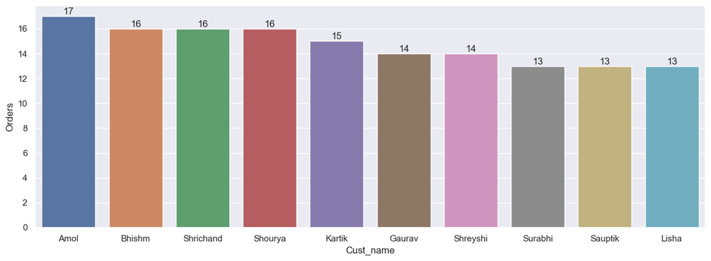

```python
#Customers:
#Which customers is more orders the product/items on top 10 customers:
cust1=df.groupby('Cust_name',as_index=False)['Orders'].sum().sort_values(by='Orders',ascending=False).head(10)

sns.set(rc={'figure.figsize':(15,5)})
cust1_count=sns.barplot(x='Cust_name',y='Orders',data=cust1)

for i in cust1_count.containers:
    cust1_count.bar_label(i)
```

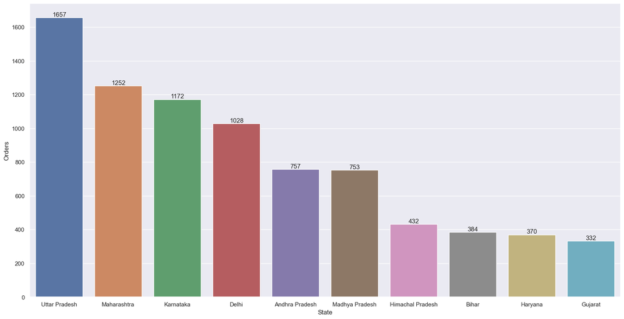

```python
#States:
#Which states is more orders the product/items on top 10:
states=df.groupby(['State'],as_index=False)['Orders'].sum().sort_values(by='Orders',ascending=False).head(10)

sns.set(rc={'figure.figsize':(20,10)})
states_count=sns.barplot(x='State',y='Orders',data=states)

for i in states_count.containers:
    states_count.bar_label(i)
```

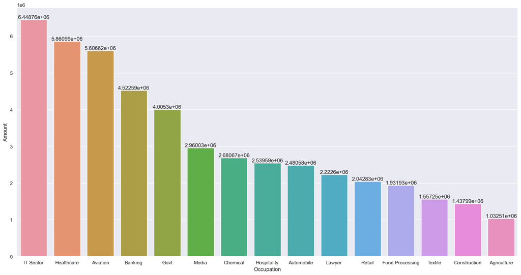

```python
#Occupation:
#1.Which occupation is more spending the money for order in top 10 :
occupation=df.groupby(['Occupation'],as_index=False)['Amount'].sum().sort_values(by='Amount',ascending=False)

occu_count=sns.barplot(x='Occupation',y='Amount',data=occupation)

for i in occu_count.containers:
    occu_count.bar_label(i)
```

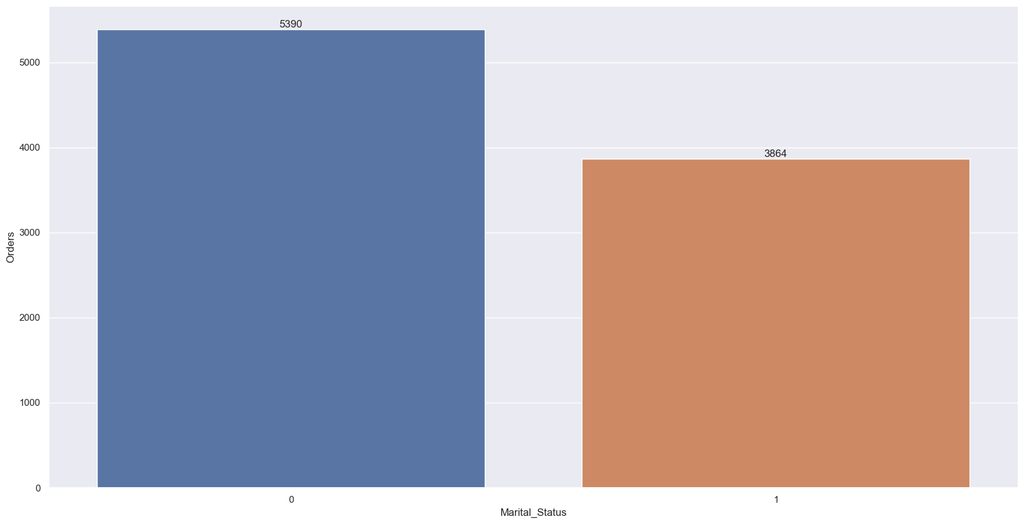

```python
#Marital:
#Which marital/non-marital person is more orders the product/items:
marital=df.groupby(['Marital_Status'],as_index=False)['Orders'].sum().sort_values(by='Orders',ascending=False)

marital_count=sns.barplot(x='Marital_Status',y='Orders',data=marital)

for i in marital_count.containers:
    marital_count.bar_label(i)
```

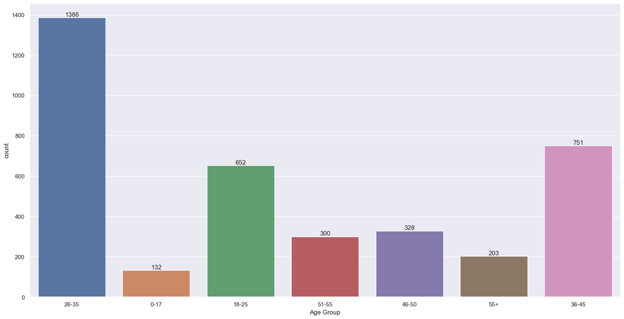

```python
#Age group:
#1.count of age group:
age=sns.countplot(x='Age Group',data=df)

for i in age.containers:
    age.bar_label(i)
```

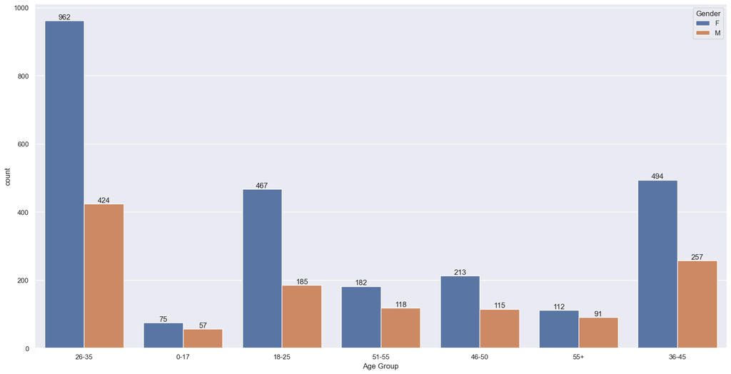

```python
#2.count of age group in gender:
age=sns.countplot(x='Age Group',hue='Gender',data=df)

for i in age.containers:
    age.bar_label(i)
```

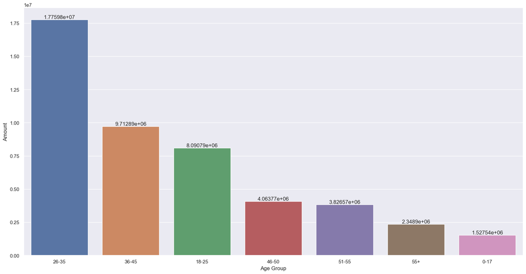

```python
#3.Which age group is spending the more amount for shopping:
age=df.groupby(['Age Group'],as_index=False)['Amount'].sum().sort_values(by='Amount',ascending=False)
age_count=sns.barplot(x='Age Group',y='Amount',data=age)

for i in age_count.containers:
    age_count.bar_label(i)
```

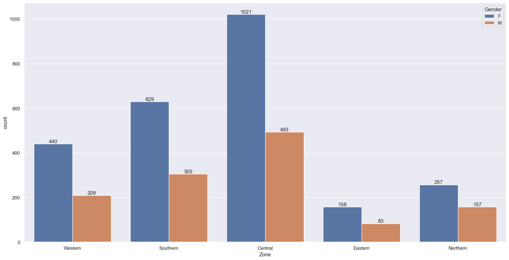

```python
#Zone:
#Count of zone:
zone=sns.countplot(x='Zone',hue='Gender',data=df)

for i in zone.containers:
    zone.bar_label(i)
```

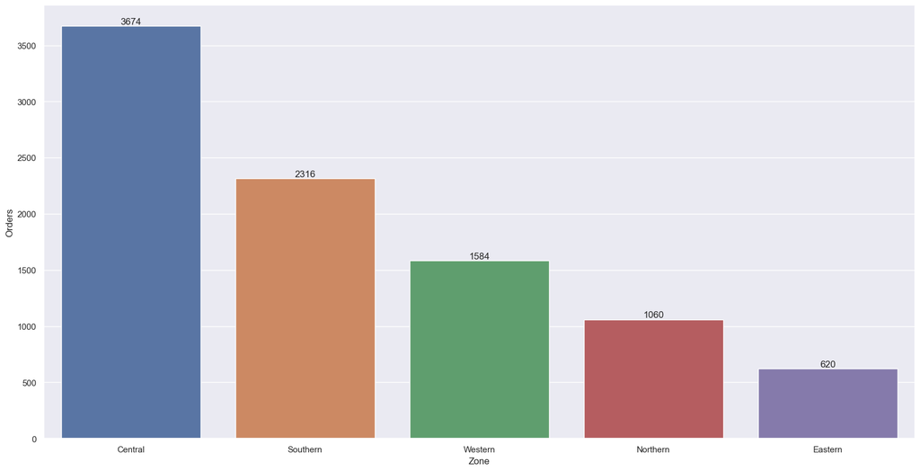

```python
#which zone is more orders the product:
zone=df.groupby(['Zone'],as_index=False)['Orders'].sum().sort_values(by='Orders',ascending=False)
zone_count=sns.barplot(x='Zone',y='Orders',data=zone)

for i in zone_count.containers:
    zone_count.bar_label(i)
```

# Conclusion

*In summary, the predominant demographic displaying heightened interest in pursuing the specified analysis data comprises unmarried females within the age range of 26 to 35. This trend is particularly pronounced among residents of Uttar Pradesh, specifically those employed in the IT sector. Notably, individuals situated in the central zone exhibit a notable inclination towards pursuing the identified patterns and preferences.*